# Between-Sample (Beta) Diversity of Microbes in Snail Gut Microbiomes at Three Temperatures

Daphne Garcia

2025-04-16

# Set up the Environment

```r
# What time did we start running this script?
start_time <- Sys.time()

set.seed(238428)

pacman::p_load(tidyverse, devtools, phyloseq, patchwork, vegan,
               install = FALSE)

source("code/colors.R")

source("code/functions.R")
```

INTERPRETATION #1: What is your scientific question and hypotheses? Do they relate to abundance? Presence/absence? Phylogeny?

My question is whether there will be a difference in the composition of the Snail gut microbiomes between three different temperatures (control, high temp, low temp). I predict that there will be a more even abundance at control and lower temperatures, and that some species will rise to high dominance at high temperature. However, I predict that there will be more species present at control and lower temperatures than at high temperatures. H0: There will be no change in microbial composition of snail gut microbiomes across three temperatures (high temperature, low temperature, control temperature)

HA: Microbial composition will differ in gut microbiomes at high temperature compared to low/control temperatures.

HA2: There will be significantly less species present in high temperature samples compared to low/control samples

# Load data

```r
# load phyloseq object
load("data/04_PhylogeneticTree/phytree_preprocessed_physeqs.RData")
midpoint_rooted_physeq
```

```
## phyloseq-class experiment-level object
## otu_table()   OTU Table:         [ 17799 taxa and 60 samples ]
## sample_data() Sample Data:       [ 60 samples by 38 sample variables ]
## tax_table()   Taxonomy Table:    [ 17799 taxa by 9 taxonomic ranks ]
## phy_tree()    Phylogenetic Tree: [ 17799 tips and 17798 internal nodes ]
```

```r
# Intuition check on seq depth
min(sample_sums(midpoint_rooted_physeq))
```

```
## [1] 39242
```

```r
######## REMOVE TWO OUTLIERS: Unnecessary
# midpoint_rooted_physeq <-
#   midpoint_rooted_physeq %>%
#   subset_samples(names != "SRR19509114") %>%
#   subset_samples(names != "SRR19509116") %>%
#   # And remove any ASVs unique to this sample, just in case.
#   prune_taxa(taxa_sums(.) > 0, .)
#
# # Check that we now have 88 samples
# midpoint_rooted_physeq
############################



# Create Metadata_df
metadata_df <-
  midpoint_rooted_physeq %>%
  sample_data() %>%
  data.frame()

head(metadata_df)
```

```
##             Assay.Type AvgSpotLen    Bases  BioProject    BioSample
## SRR19509095   AMPLICON        500 54925500 PRJNA843708 SAMN28766924
## SRR19509096   AMPLICON        500 50099000 PRJNA843708 SAMN28766923
## SRR19509097   AMPLICON        500 55474000 PRJNA843708 SAMN28766922
## SRR19509098   AMPLICON        500 55287500 PRJNA843708 SAMN28766921
## SRR19509099   AMPLICON        500 57233000 PRJNA843708 SAMN28766974
## SRR19509100   AMPLICON        500 54169000 PRJNA843708 SAMN28766973
##                          BioSampleModel    Bytes                 Center.Name
## SRR19509095 Metagenome or environmental 18249721 NANJING FORESTRY UNIVERSITY
## SRR19509096 Metagenome or environmental 16578763 NANJING FORESTRY UNIVERSITY
## SRR19509097 Metagenome or environmental 18304676 NANJING FORESTRY UNIVERSITY
## SRR19509098 Metagenome or environmental 18219402 NANJING FORESTRY UNIVERSITY
## SRR19509099 Metagenome or environmental 18702068 NANJING FORESTRY UNIVERSITY
## SRR19509100 Metagenome or environmental 17860015 NANJING FORESTRY UNIVERSITY
##             Collection_Date Consent DATASTORE.filetype DATASTORE.provider
## SRR19509095         2021-10  public   run.zq,sra,fastq         s3,gs,ncbi
## SRR19509096         2021-10  public   fastq,sra,run.zq         ncbi,s3,gs
## SRR19509097         2021-10  public   sra,run.zq,fastq         ncbi,gs,s3
## SRR19509098         2021-10  public   sra,fastq,run.zq         ncbi,gs,s3
## SRR19509099         2021-11  public   sra,fastq,run.zq         gs,s3,ncbi
## SRR19509100         2021-11  public   fastq,sra,run.zq         gs,s3,ncbi
##                                 DATASTORE.region  Experiment
## SRR19509095 gs.us-east1,s3.us-east-1,ncbi.public SRX15561738
## SRR19509096 gs.us-east1,s3.us-east-1,ncbi.public SRX15561737
## SRR19509097 ncbi.public,gs.us-east1,s3.us-east-1 SRX15561736
## SRR19509098 ncbi.public,gs.us-east1,s3.us-east-1 SRX15561735
## SRR19509099 ncbi.public,s3.us-east-1,gs.us-east1 SRX15561734
## SRR19509100 gs.us-east1,s3.us-east-1,ncbi.public SRX15561733
##             geo_loc_name_country geo_loc_name_country_continent  geo_loc_name
## SRR19509095                China                           Asia China: Suzhou
## SRR19509096                China                           Asia China: Suzhou
## SRR19509097                China                           Asia China: Suzhou
## SRR19509098                China                           Asia China: Suzhou
## SRR19509099                China                           Asia China: Suzhou
## SRR19509100                China                           Asia China: Suzhou
##                             Host            Instrument isolation_source
## SRR19509095 Pomacea canaliculata Illumina NovaSeq 6000    gut content10
## SRR19509096 Pomacea canaliculata Illumina NovaSeq 6000     gut content9
## SRR19509097 Pomacea canaliculata Illumina NovaSeq 6000     gut content8
## SRR19509098 Pomacea canaliculata Illumina NovaSeq 6000     gut content7
```

[output cut: 15 more lines]

```
## SRR19509100   METAGENOMIC gut metagenome ILLUMINA  2024-05-30
##                     create_date version Sample.Name SRA.Study       names
## SRR19509095 2022-06-01 14:59:00       1         CF6 SRP378042 SRR19509095
## SRR19509096 2022-06-01 14:59:00       1         CF5 SRP378042 SRR19509096
## SRR19509097 2022-06-01 14:59:00       1         CF4 SRP378042 SRR19509097
## SRR19509098 2022-06-01 14:59:00       1         CF3 SRP378042 SRR19509098
## SRR19509099 2022-06-01 14:59:00       1        LF12 SRP378042 SRR19509099
## SRR19509100 2022-06-01 14:59:00       1        LF11 SRP378042 SRR19509100
##             denoisedF denoisedR merged nochim num_ASVs
## SRR19509095     94686     94497  87854  67016      419
## SRR19509096     86700     86185  81615  51886      348
## SRR19509097     96278     96091  91155  63907      372
## SRR19509098     95458     95003  88314  58152      471
## SRR19509099    102411    102405  89705  53191      661
## SRR19509100     96536     96742  87311  62810      618
```

## Mutate metadata to have snail info

```r
## ADD A COLUMN FOR EXPEIMENTAL GROUP, SEX, AND TEMPERATURE

metadata_df <- metadata_df %>%
  mutate(snail_exp_group_name = substr(Sample.Name, 1, 2)) %>%
  mutate(temperature = substr(Sample.Name, 1, 1)) %>%
  mutate(sex = substr(Sample.Name, 2, 2))
```

# Normalizing the Read Depth

## 2. Explore the Raw Read Counts

```r
# calculate read counts per sample
raw_TotalSeqs_df <-
  midpoint_rooted_physeq %>%
  # Calculate the total number of sequences/reads
  sample_sums() %>%
  data.frame()

# Take a look
head(raw_TotalSeqs_df)
```

```
##                 .
## SRR19509095 67014
## SRR19509096 51886
## SRR19509097 63907
## SRR19509098 58117
## SRR19509099 53191
## SRR19509100 62810
```

```r
# Rename the column
colnames(raw_TotalSeqs_df)[1] <- "TotalSeqs"

# add a new column of num_ASVs (RAW, non-noramlized # ASVs)
raw_TotalSeqsASVs_df <-
  raw_TotalSeqs_df %>%
  mutate(num_ASVs = colSums(otu_table(midpoint_rooted_physeq) > 1))

#View(raw_TotalSeqsASVs_df)

# Plot histogram of seq depth
rawSeq_histogram <-
  raw_TotalSeqsASVs_df %>%
  ggplot(aes(x = TotalSeqs)) +
  geom_histogram(bins = 50) +
  scale_x_continuous(limits = c(30000, 80000)) + #changed limits
  labs(title = "Raw Seq Depth Histogram") +
  theme_bw()

# Plot Seq Depth versus num_ASVs
rawSeq_vs_numASV_plot <-
  raw_TotalSeqsASVs_df %>%
  ggplot(aes(x = num_ASVs, y = TotalSeqs)) +
  geom_point() +
  scale_y_continuous(limits = c(30000, 80000)) + ## changed limits
  geom_smooth(method = "lm") +
  labs(title = "Seq Depth vs # ASVs") +
  theme_bw()

# is it significant?
summary(lm(TotalSeqs ~ num_ASVs, data = raw_TotalSeqsASVs_df))
```

```
##
## Call:
## lm(formula = TotalSeqs ~ num_ASVs, data = raw_TotalSeqsASVs_df)
##
## Residuals:
##    Min     1Q Median     3Q    Max
## -19619  -4539    -36   5356  17436
##
## Coefficients:
##             Estimate Std. Error t value Pr(>|t|)
## (Intercept) 66198.96    2687.91  24.628   <2e-16 ***
## num_ASVs      -13.90       4.55  -3.055   0.0034 **
## ---
## Signif. codes:  0 '***' 0.001 '**' 0.01 '*' 0.05 '.' 0.1 ' ' 1
##
## Residual standard error: 7719 on 58 degrees of freedom
## Multiple R-squared:  0.1386, Adjusted R-squared:  0.1237
## F-statistic: 9.331 on 1 and 58 DF,  p-value: 0.003401
```

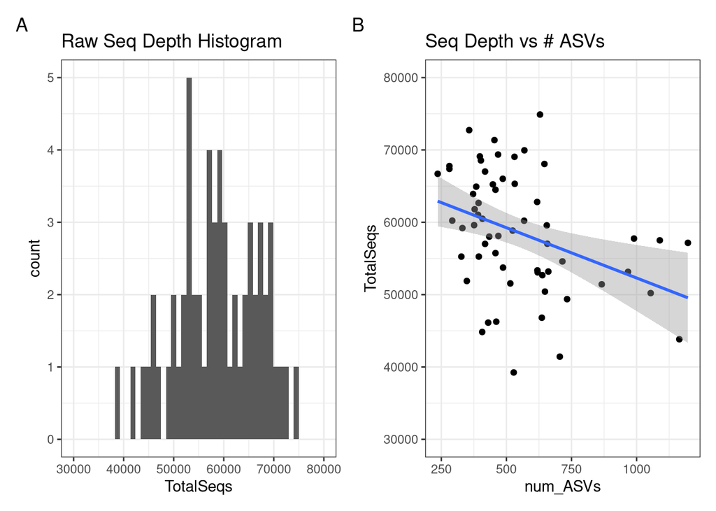

```r
# Put the two plots together.
rawSeq_histogram + rawSeq_vs_numASV_plot +
  plot_annotation(tag_levels = "A")
```

Summary of Seq depth vs num_ASVs Multiple R-squared: 0.1386, Adjusted R-squared: 0.1237 F-statistic: 9.331 on 1 and 58 DF, p-value: 0.003401

INTERPRETATION #2: Evaluating the above plots, what did you scale the read counts to in your dataset? Why did you choose that number? Do you think it is sufficient to perform a beta-diversity analysis and accurately compare your data to one another?

I am scaling to my minimum read count across samples, which is 39242. When statistically checking the relationship between the sequencing depth and number of ASV’s, the R^2 is 0.139, which indicates that only 13.9% of the variation in ASV count is explained by sequencing depth. Since this is a weak correlation, it suggests that there is a weak correlation between sequencing depth and ASVs, which might mean that beta diversity metrics won’t be overly skewed by sequencing depth.

The p value is 0.003, which indicates that the relationship is significant, so I didn’t need to remove any outliers. Therefore, using the minimum read counts, 39k, was sufficient as a scale. Additionally, the raw sequencing depth histogram appears to have a normal distribution. Based on these points, I think that scaling to the minimum reads across samples, 39242, is enough to perform beta diversity analysis.